# Network Analytics in R: Chapter 4 of 4

jy

2021-12-23

## Chapter 4: Identifying Special Relationships

Notes from DataCamp course [‘Network Analysis in R’](https://learn.datacamp.com/courses/network-analysis-in-r) **Chapter 4: Identifying Special Relationships.**

## Key Concepts

- Assortativity: preferential attachwent of vertices to others that share similar attributes (numerical or categorical). Values from -1 to 1.
- Reciprocity: proportion of edges that are both directions.
- Community detection: more advanced approach than assortativity and reciprocity for understanding groups/clusters/communities within a network
  - fastgreedy.community: like ‘inside-out’ method
  - edge.betweenness.community: sort of ‘outside-in’ method

## Get / Explore Data

Datacamp exercises use Forrest Gump movie character network data - pairs of actors who appear in at least one scene together.

```r
## get list of datasets in igraphdata
data(package='igraphdata')
## import data set
data('UKfaculty', package='igraphdata')

## get description of UKfaculty
UKfaculty
```

```
## IGRAPH 6f42903 D-W- 81 817 --
## + attr: Type (g/c), Date (g/c), Citation (g/c), Author (g/c), Group
## | (v/n), weight (e/n)
## + edges from 6f42903:
##  [1] 57->52 76->42 12->69 43->34 28->47 58->51  7->29 40->71  5->37 48->55
## [11]  6->58 21-> 8 28->69 43->21 67->58 65->42  5->67 52->75 37->64  4->36
## [21] 12->49 19->46 37-> 9 74->36 62-> 1 15-> 2 72->49 46->62  2->29 40->12
## [31] 22->29 71->69  4-> 3 37->69  5-> 6 77->13 23->49 52->35 20->14 62->70
## [41] 34->35 76->72  7->42 37->42 51->80 38->45 62->64 36->53 62->77 17->61
## [51]  7->68 46->29 44->53 18->58 12->16 72->42 52->32 58->21 38->17 15->51
## [61] 22-> 7 22->69  5->13 29-> 2 77->12 37->35 18->46 10->71 22->47 20->19
## + ... omitted several edges
```

From this we can tell:

- Directed graph (D in D-W-)
- Not named graph: doesn’t have ‘name’ attribute for vertices (no N in DNW)
- Weighted graph (W in D-W)
- 81 vertices
- 817 edges
- attributes:
  - graph: Type (character), Date (character), Citation (character), Author (character)
  - vertices: Group (number)
  - edges: weight (edges/number)

[Some explanation in official documentation here](https://igraph.org/r/doc/aaa-igraph-package.html)

## Preview Data

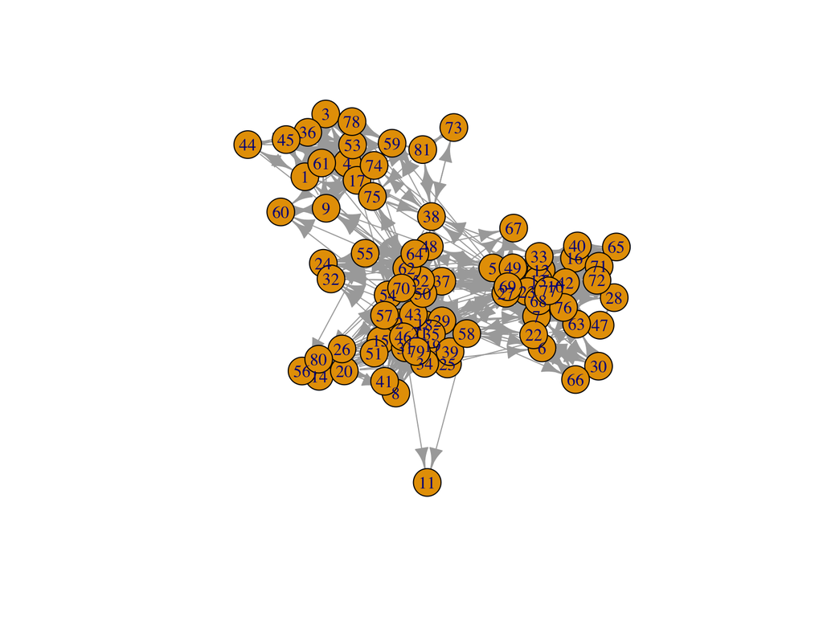

```r
plot(UKfaculty)
```

## Assortativity & Reciprocity

### Assortativity

Calculate assortativity:

- ‘Group’ is only vertex attribute, so will need to use that
- Group is already numeric, otherwise would have to convert to factor and then numeric

```r
assortativity(UKfaculty, V(UKfaculty)$Group)
```

```
## [1] 0.5509642
```

```r
assortativity.degree(UKfaculty, directed=TRUE)
```

```
## [1] 0.03805201
```

### Randomization for Assessment

We now have values for assortativity and assortativity degree but hard to know how meaninful they are until we compare with randomization.

Randomization will help us to assess the values by comparing them to how likely the observed values are.

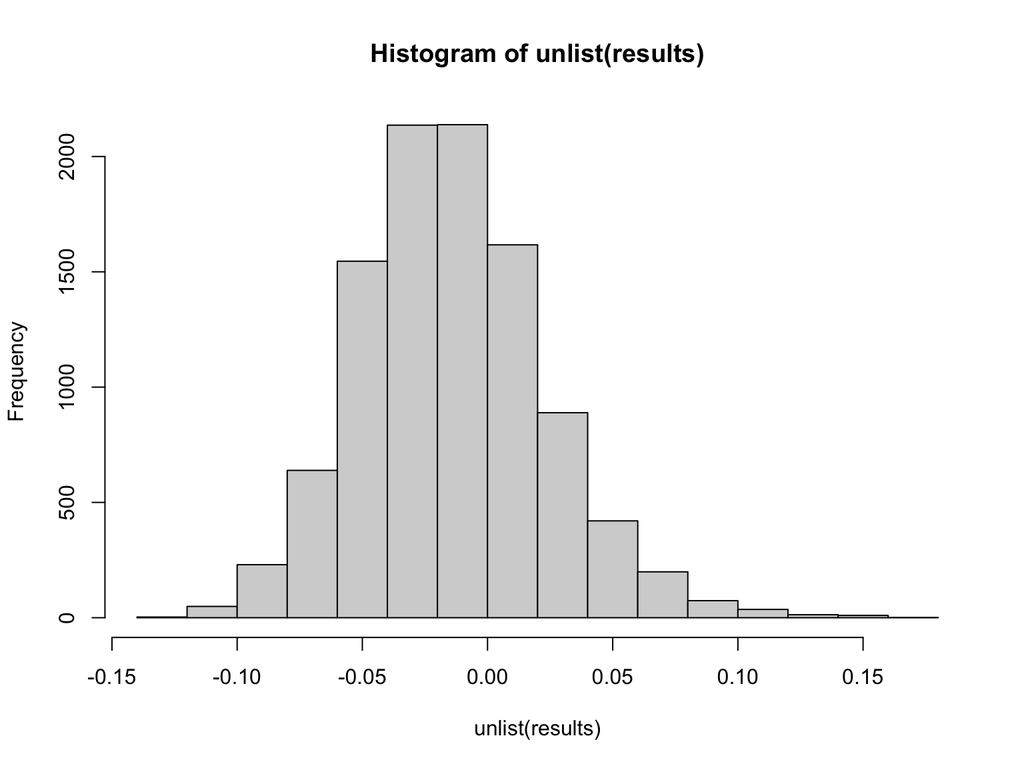

```r
observed.assort <- assortativity(UKfaculty, V(UKfaculty)$Group)

results <- vector('list', 1000)
for(i in 1:10000){
  results[[i]] <- assortativity(UKfaculty, sample(V(UKfaculty)$Group))
}

## Plot
hist(unlist(results))
abline(v = observed.assort, col='red', lty=3, lwd=2)
```

Observed assortativity is not shown because it is beyond range of randomization histogram. So I guess it is relatively HIGH!

### Reciprocity

Check reciprocity

```r
reciprocity(UKfaculty)
```

```
## [1] 0.5875153
```

## Community Detection

Back to Karate network data - same as used in DataCamp course.

```r
## import data set
data('karate', package='igraphdata')

## check data
karate
```

```
## IGRAPH 4b458a1 UNW- 34 78 -- Zachary's karate club network
## + attr: name (g/c), Citation (g/c), Author (g/c), Faction (v/n), name
## | (v/c), label (v/c), color (v/n), weight (e/n)
## + edges from 4b458a1 (vertex names):
##  [1] Mr Hi  --Actor 2  Mr Hi  --Actor 3  Mr Hi  --Actor 4  Mr Hi  --Actor 5
##  [5] Mr Hi  --Actor 6  Mr Hi  --Actor 7  Mr Hi  --Actor 8  Mr Hi  --Actor 9
##  [9] Mr Hi  --Actor 11 Mr Hi  --Actor 12 Mr Hi  --Actor 13 Mr Hi  --Actor 14
## [13] Mr Hi  --Actor 18 Mr Hi  --Actor 20 Mr Hi  --Actor 22 Mr Hi  --Actor 32
## [17] Actor 2--Actor 3  Actor 2--Actor 4  Actor 2--Actor 8  Actor 2--Actor 14
## [21] Actor 2--Actor 18 Actor 2--Actor 20 Actor 2--Actor 22 Actor 2--Actor 31
## [25] Actor 3--Actor 4  Actor 3--Actor 8  Actor 3--Actor 9  Actor 3--Actor 10
## + ... omitted several edges
```

### fastgreedy.community

```r
fgc <- fastgreedy.community(karate)
sizes(fgc)
```

```
## Community sizes
##  1  2  3
## 18 11  5
```

```r
membership(fgc)
```

```
##    Mr Hi  Actor 2  Actor 3  Actor 4  Actor 5  Actor 6  Actor 7  Actor 8
##        2        2        2        2        3        3        3        2
##  Actor 9 Actor 10 Actor 11 Actor 12 Actor 13 Actor 14 Actor 15 Actor 16
##        1        1        3        2        2        2        1        1
## Actor 17 Actor 18 Actor 19 Actor 20 Actor 21 Actor 22 Actor 23 Actor 24
##        3        2        1        2        1        2        1        1
## Actor 25 Actor 26 Actor 27 Actor 28 Actor 29 Actor 30 Actor 31 Actor 32
##        1        1        1        1        1        1        1        1
## Actor 33   John A
##        1        1
```

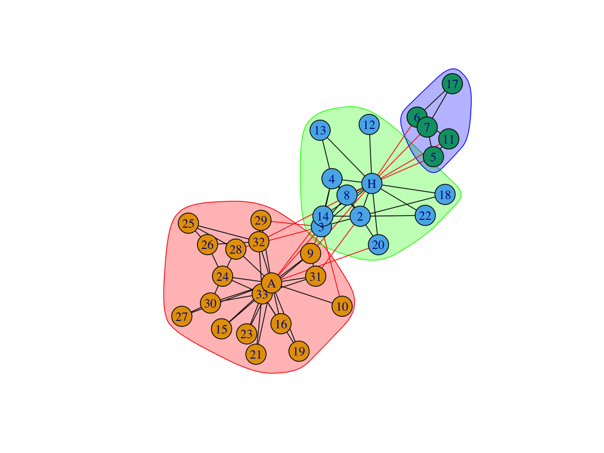

```r
plot(fgc, karate)
```

### edge.betweenness.community

```r
ebc <- edge.betweenness.community(karate)
sizes(ebc)
```

```
## Community sizes
##  1  2  3  4  5  6
##  9  4  5 10  4  2
```

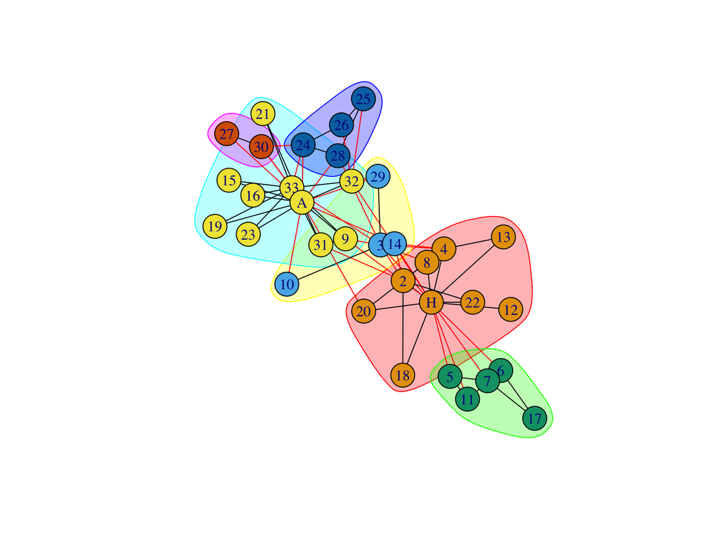

```r
plot(ebc, karate)
```

### Compare Plots

Plot fastgreedy.community and edge.betweenness.community side by side

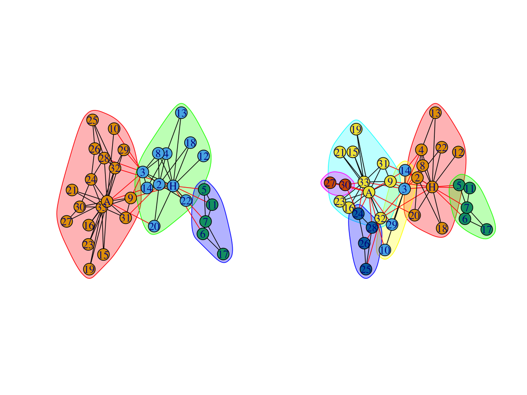

```r
par(mfrow=c(1,2))
plot(fgc, karate)
plot(ebc, karate)
```

### leading.eigenvector.community

```r
lec <- leading.eigenvector.community(karate)
sizes(lec)
```

```
## Community sizes
##  1  2  3  4  5
## 10 12  5  1  6
```

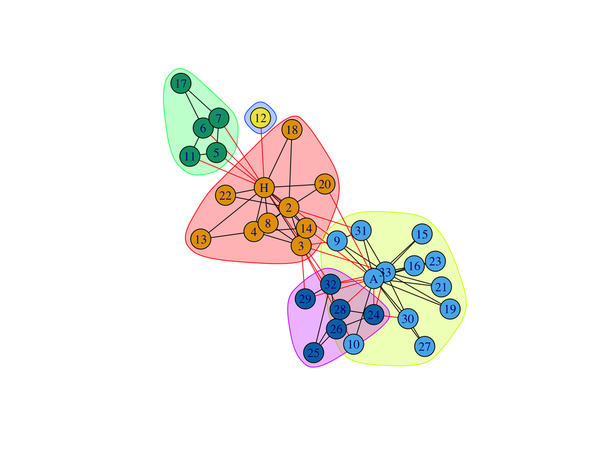

```r
plot(lec, karate)
```

## Network visualizations

Other packages beyond **igraph** can be used:

- statnet
- ggnet
- ggnetwork
- ggraph
- visNetwork
- networkD3
- sigma
- rgexf (igraph to Gephi)
- **threejs**

### threejs for interactivity

Using threejs package for interactive network plots.

```r
UKfaculty <- set_vertex_attr(UKfaculty, 'color', value='dodgerblue')
graphjs(UKfaculty, vertex.size = 1)
```

[interactive chart not shown]

Set size based on eigen centrality:

```r
g <- karate
ec <- as.numeric(eigen_centrality(g)$vector)

v <- 5 * sqrt(ec)

graphjs(g, vertex.size=ec)
```

[interactive chart not shown]

Color based on community membership

```r
## create object containing memberships from fastgreedy.community detection above
i <- membership(fgc)
## check sizes
sizes(fgc)
```

```
## Community sizes
##  1  2  3
## 18 11  5
```

```r
## add color to each vertex based on community
karate <- set_vertex_attr(karate, "color", value=c("yellow","red","blue")[i])
## plot with threejs
graphjs(karate)
```

[interactive chart not shown]